# EDA_song

yongwen

2018年7月25日

# 介紹

這些資料裡包含一些音軌的特徵  
**Spotify’s Top Songs of 2017** 而我試著分析這些音樂背後的特徵

# Read the Data

```r
library(readr)
library(plyr)
library(dplyr)
library(ggplot2)
library(formattable)
library(wordcloud)
library(tm)

spotify_data <- read_csv('./featuresdf.csv')
daily_spotify <- read_csv('./data.csv')
```

```r
glimpse(spotify_data)
```

```
## Observations: 100
## Variables: 16
## $ id               <chr> "7qiZfU4dY1lWllzX7mPBI", "5CtI0qwDJkDQGwXD1H1...
## $ name             <chr> "Shape of You", "Despacito - Remix", "Despaci...
## $ artists          <chr> "Ed Sheeran", "Luis Fonsi", "Luis Fonsi", "Th...
## $ danceability     <dbl> 0.825, 0.694, 0.660, 0.617, 0.609, 0.904, 0.6...
## $ energy           <dbl> 0.652, 0.815, 0.786, 0.635, 0.668, 0.611, 0.5...
## $ key              <dbl> 1, 2, 2, 11, 7, 1, 0, 6, 1, 0, 11, 2, 5, 3, 2...
## $ loudness         <dbl> -3.183, -4.328, -4.757, -6.769, -4.284, -6.84...
## $ mode             <dbl> 0, 1, 1, 0, 1, 0, 1, 1, 1, 1, 0, 1, 0, 0, 1, ...
## $ speechiness      <dbl> 0.0802, 0.1200, 0.1700, 0.0317, 0.0367, 0.088...
## $ acousticness     <dbl> 0.581000, 0.229000, 0.209000, 0.049800, 0.055...
## $ instrumentalness <dbl> 0.00e+00, 0.00e+00, 0.00e+00, 1.44e-05, 0.00e...
## $ liveness         <dbl> 0.0931, 0.0924, 0.1120, 0.1640, 0.1670, 0.097...
## $ valence          <dbl> 0.9310, 0.8130, 0.8460, 0.4460, 0.8110, 0.400...
## $ tempo            <dbl> 95.977, 88.931, 177.833, 103.019, 80.924, 150...
## $ duration_ms      <dbl> 233713, 228827, 228200, 247160, 288600, 17700...
## $ time_signature   <dbl> 4, 4, 4, 4, 4, 4, 4, 4, 4, 4, 4, 4, 4, 4, 4, ...
```

```r
summary(spotify_data)
```

```
##       id                name             artists           danceability
##  Length:100         Length:100         Length:100         Min.   :0.2580
##  Class :character   Class :character   Class :character   1st Qu.:0.6350
##  Mode  :character   Mode  :character   Mode  :character   Median :0.7140
##                                                           Mean   :0.6968
##                                                           3rd Qu.:0.7702
##                                                           Max.   :0.9270
##      energy            key           loudness            mode
##  Min.   :0.3460   Min.   : 0.00   Min.   :-11.462   Min.   :0.00
##  1st Qu.:0.5565   1st Qu.: 2.00   1st Qu.: -6.595   1st Qu.:0.00
##  Median :0.6675   Median : 6.00   Median : -5.437   Median :1.00
##  Mean   :0.6607   Mean   : 5.57   Mean   : -5.653   Mean   :0.58
##  3rd Qu.:0.7875   3rd Qu.: 9.00   3rd Qu.: -4.327   3rd Qu.:1.00
##  Max.   :0.9320   Max.   :11.00   Max.   : -2.396   Max.   :1.00
##   speechiness       acousticness      instrumentalness
##  Min.   :0.02320   Min.   :0.000259   Min.   :0.000e+00
##  1st Qu.:0.04312   1st Qu.:0.039100   1st Qu.:0.000e+00
##  Median :0.06265   Median :0.106500   Median :0.000e+00
##  Mean   :0.10397   Mean   :0.166306   Mean   :4.796e-03
##  3rd Qu.:0.12300   3rd Qu.:0.231250   3rd Qu.:1.335e-05
##  Max.   :0.43100   Max.   :0.695000   Max.   :2.100e-01
##     liveness          valence           tempo         duration_ms
##  Min.   :0.04240   Min.   :0.0862   Min.   : 75.02   Min.   :165387
##  1st Qu.:0.09828   1st Qu.:0.3755   1st Qu.: 99.91   1st Qu.:198491
##  Median :0.12500   Median :0.5025   Median :112.47   Median :214106
##  Mean   :0.15061   Mean   :0.5170   Mean   :119.20   Mean   :218387
##  3rd Qu.:0.17925   3rd Qu.:0.6790   3rd Qu.:137.17   3rd Qu.:230543
##  Max.   :0.44000   Max.   :0.9660   Max.   :199.86   Max.   :343150
##  time_signature
##  Min.   :3.00
##  1st Qu.:4.00
##  Median :4.00
##  Mean   :3.99
##  3rd Qu.:4.00
##  Max.   :4.00
```

```r
spotify_data$duration_ms <- round(spotify_data$duration_ms / 1000)
colnames(spotify_data)[15] <- "duration"
```

# 資料分析

## Artists dominating the Top List

用來判定哪些歌手有超過一首歌進入前100名

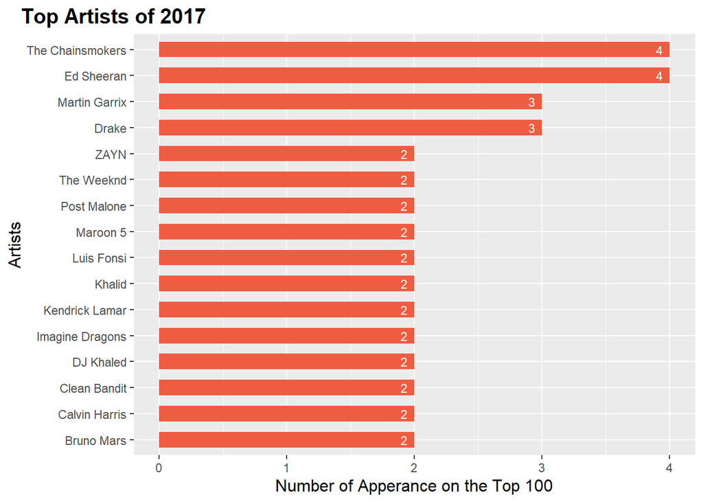

```r
top_artists <- spotify_data %>%
    group_by(artists)  %>%
    summarise(n_apperance = n()) %>%
    filter(n_apperance > 1) %>%
    arrange(desc(n_apperance))

top_artists$artists <- factor(top_artists$artists, levels = top_artists$artists[order(top_artists$n_apperance)]) # in order to visualise the list in descending order

ggplot(top_artists, aes(x = artists, y = n_apperance)) +
    geom_bar(stat = "identity",  fill = "tomato2", width = 0.6 ) +
    labs(title = "Top Artists of 2017", x = "Artists", y = "Number of Apperance on the Top 100") +
    theme(plot.title = element_text(size=15,hjust=-.3,face = "bold"), axis.title = element_text(size=12)) +
    geom_text(aes(label=n_apperance), hjust = 2, size = 3, color = 'white') +
    coord_flip()
```

由此可知，Ed sheeran和The Chainsmokers 有四首不同的歌進入前100名的歌單，而Drake和Martin Garrix有三首不同的歌

## 用播放次數排名歌手

用spotify_data裡的duration 變數和daily spotify裡的steam變數來判定

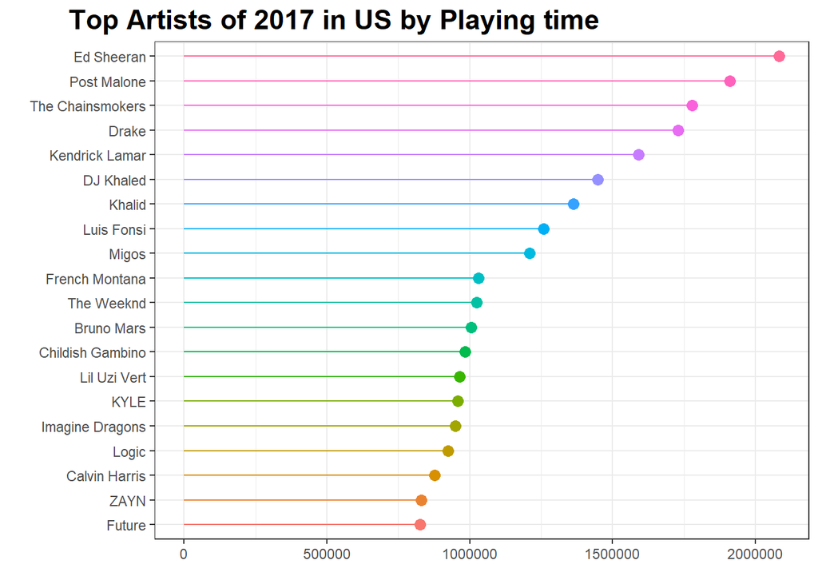

```r
us_daily_spotify <- daily_spotify %>%
    filter(Region == "us") %>%
    group_by(`Track Name`) %>%
    summarise(total_streams = sum(Streams))

names(us_daily_spotify)[1] <- paste("name") # in order to make the joining easier

top_by_playtime <- spotify_data %>%
    left_join(us_daily_spotify, by = "name") %>%
    select(name, artists, duration, total_streams) %>%
    mutate(total_time = duration * total_streams / 60000) # in order to convert seconds into hours

top20_by_playtime <-  top_by_playtime %>%
    group_by(artists)  %>%
    summarise(n_time = sum(total_time)) %>%
    arrange(desc(n_time)) %>%
    top_n(20)

top20_by_playtime$artists <- factor(top20_by_playtime$artists, levels = top20_by_playtime$artists [order(top20_by_playtime$n_time)]) # in order to visualise the list in descending order

ggplot(top20_by_playtime, aes(x=artists, y=n_time, color=artists)) +
    geom_point(size=3) +
    geom_segment(aes(x=artists,xend=artists, y=0, yend=n_time)) +
    labs(title = "Top Artists of 2017 in US by Playing time", x='',y='') +
    theme_bw() +
    theme(legend.position = 'none', plot.title = element_text(size=17,hjust = -0.7, face = "bold"), axis.title.y = element_text(face = "bold"), axis.title.x = element_text(angle = 120)) +
    coord_flip()
```

現在Post Malone變成第二名了，我們用撥放次數之後Ed Sheeran依然是第一名，但Post Malone 和Kendrick Lamar和上一個資料分析方式比起來名次往前了

```r
ed_sheeran_daily <- daily_spotify %>%
    filter(Region == "us", Artist == "Ed Sheeran", Position <= 100)

formatted_ed <- ed_sheeran_daily %>%
    group_by(`Track Name`) %>%
    summarise(n_daily = n()) %>%
    arrange(desc(n_daily))

formattable(formatted_ed)
```

| Track Name | n_daily |
| --- | --- |
| Shape of You | 364 |
| Perfect | 148 |
| Castle on the Hill | 104 |
| Galway Girl | 62 |
| Perfect Duet (Ed Sheeran & Beyonce) | 39 |
| Happier | 35 |
| Dive | 31 |
| New Man | 22 |
| How Would You Feel (Paean) | 20 |
| What Do I Know? | 19 |
| Barcelona | 17 |
| Supermarket Flowers | 17 |
| Nancy Mulligan | 16 |
| Hearts Don’t Break Around Here | 15 |
| Bibia Be Ye Ye | 14 |
| Eraser | 14 |
| Save Myself | 14 |
| Thinking Out Loud | 6 |
| Photograph | 5 |

## 變數間的關聯

運用 `corrplot` function 去作圖分析

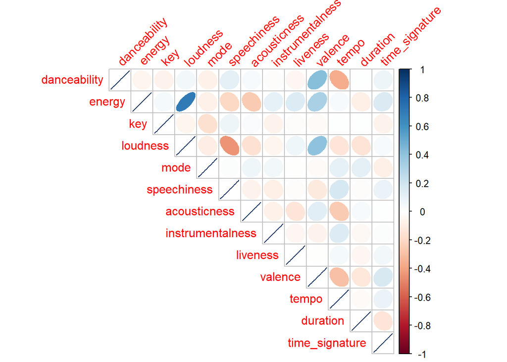

```r
library(corrplot)
spotify_data_num <- spotify_data[,-(1:3)]
mtCor <- cor(spotify_data_num)
corrplot(mtCor, method = "ellipse", type = "upper", tl.srt = 45)
```

*energy和loudness呈現非常正相關* valence是正相關於danceability和energy *還有特別的是speechiness和loudness兩者呈現非常負相關

## Top songs的普遍特徵

### ㄔ常用的音頻或曲調keys

[figure not shown]

```r
spotify_data$key <- as.character(spotify_data$key)
spotify_data$key <- revalue(spotify_data$key, c("0" = "C", "1" = "C♯,D♭", "2" = "D", "3" = "D♯,E♭", "4" = "E", "5" =  "F", "6" = "F♯,G♭","7" = "G","8" = "G♯,A♭","9" = "A","10" = "A♯,B♭","11" = "B"))

song_keys <- spotify_data %>%
    group_by(key) %>%
    summarise(n_key = n()) %>%
    arrange(desc(n_key))

song_keys$key <- factor(song_keys$key, levels = song_keys$key[order(song_keys$n_key)]) # in order to visualise the keys in descending order

ggplot(song_keys, aes(x = reorder(key,-n_key), y = n_key, fill = reorder(key,-n_key))) +
    geom_bar(stat = "identity") +
    labs(title = "Distribution of the Keys of Top Songs", x = "Keys", y = "Count of Keys on the Top 100") +
    geom_text(aes(label=n_key), position = position_stack(vjust = 0.8)) +
    theme_bw() +
    theme(plot.title = element_text(size=15,face = "bold"), axis.title = element_text(size=12)) +
    theme(legend.position="none")
```

由此可知常用的曲調是 **C♯,D♭**; 反之最不常用的是**D♯,E♭**

### Density Plots of Correlated Variables

我們已經知道 `energy`,`valence` and `danceability` 呈現正相關; 但我們還想知道這些變數呈現多少在於我們前100名首歌之中

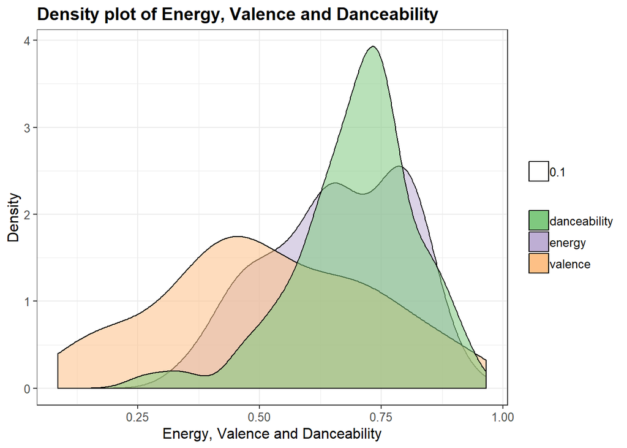

```r
correlated_density <- ggplot(spotify_data) +
    geom_density(aes(energy, fill ="energy", alpha = 0.1)) +
    geom_density(aes(valence, fill ="valence", alpha = 0.1)) +
    geom_density(aes(danceability, fill ="danceability", alpha = 0.1)) +
    scale_x_continuous(name = "Energy, Valence and Danceability") +
    scale_y_continuous(name = "Density") +
    ggtitle("Density plot of Energy, Valence and Danceability") +
    theme_bw() +
    theme(plot.title = element_text(size = 14, face = "bold"),
          text = element_text(size = 12)) +
    theme(legend.title=element_blank()) +
    scale_fill_brewer(palette="Accent")

correlated_density
```

這些變數被限制在(0,1)之中，呈現正相關